# Improved Q Learning in Multiple Environments

## Step 1: Establish Benchmark Model

### Import Libraries

```python
import pandas as pd
import numpy as np
import matplotlib.pyplot as plt
%matplotlib inline
import random
import gym
import gym_ple
from time import time, sleep
from collections import deque
```

```
couldn't import doomish
Couldn't import doom
```

### Flappy Bird Random Agent Simulation

This section runs a random agent in the Flappy Bird environment and tracks scores to establish a benchmark.

```
Random agent simulation done.
```

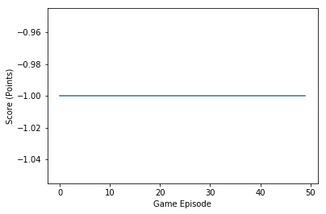

```python
# Simulation specific parameters to set.
episode_count = 50
render = False

# Initialize environment, models, and initial variables
fb_env = gym.make('FlappyBird-v0')
reward = 0
done = False
score_stats = list()


for i in range(episode_count):
    observation = fb_env.reset()
    score = 0

    while True:
        if render:
            fb_env.render()
        action = fb_env.action_space.sample()
        observation, reward, done, info = fb_env.step(action)
        if reward > 1:
            reward = 1
        if reward < -1:
            reward = -1
        score += reward

        if done:
            score_stats.append(score)
            break

fb_env.close()
print('Random agent simulation done.')

plt.plot(score_stats)
plt.ylabel('Score (Points)')
plt.xlabel('Game Episode')
plt.show()
```

### Monster Kong Random Agent Simulation

This section runs a random agent in the Monster Kong environment and tracks scores to establish a benchmark.

```
Random agent simulation done.
```

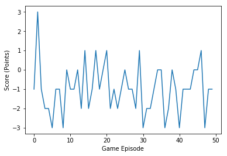

```python
mk_env = gym.make('MonsterKong-v0')

episode_count = 50
reward = 0
done = False
score_stats = list()

for i in range(episode_count):
    observation = mk_env.reset()
    score = 0
    episode_time_start = time()

    while True:
        mk_env.render()
        action = mk_env.action_space.sample()
        observation, reward, done, info = mk_env.step(action)
        if reward > 1:
            reward = 1
        if reward < -1:
            reward = -1
        score += reward

        if done or ((time() - episode_time_start) > 300):
            score_stats.append(score)
            break

mk_env.close()
print('Random agent simulation done.')

plt.plot(score_stats)
plt.ylabel('Score (Points)')
plt.xlabel('Game Episode')
plt.show()
```

## Step 2: Build the RL Model

### Hyperparameters

```python
from keras import optimizers
from keras import backend as K

# Preprocessing hyperparameters
stack_size = 4
resize_to = (100,100)

# RL model hyperparameters
training_batch_size = 15
gamma = 0.9
start_epsilon = 0.99
final_epsilon = 0.25
epsilon_episodes = 1000
ep_decay_rate = (epsilon-final_epsilon)\
                /epsilon_episodes
r_memory = deque([], maxlen=4000)
training_frequency = 4
update_frequency = 100
random_steps = 1000
action_repeat = 5

# Priority sweep hyperparameters
terminal_repeat = 2
priority_factor = 3

# CNN hyperparameter
opt = optimizers.Adam(lr=0.00025)
def clipped_mse(y_true, y_pred):
    return K.mean(K.square(K.clip((y_pred - y_true), -1, 1)), axis=-1)
```

## Preprocessing Functions

```python
from keras.preprocessing import image
from PIL import Image
import cv2

# Resize frame and convert to 4D tensor
def frame_to_tensor(frame):
    gray = cv2.cvtColor(frame, cv2.COLOR_RGB2GRAY)
    img = Image.fromarray(gray)
    img = img.resize(size=resize_to)
    x = image.img_to_array(img)
    return np.expand_dims(x, axis=0)

# Stacks the most recent frames of gameplay, according
# to above stack_size, and returns a 4D tensor
def frames_to_stacktensor(deck):
    tensor_list = list()
    sequence = list(deck)
    if len(sequence) < stack_size:
        for i in range(len(sequence)):
            x = frame_to_tensor(sequence[i])
            tensor_list.append(x)
        while len(tensor_list) < stack_size:
            black_frame = np.array([[[0,0,0],[0,0,0]],
                             [[0,0,0],[0,0,0]]], np.uint8)
            x = frame_to_tensor(black_frame)
            tensor_list.append(x)
    else:
        for item in sequence[-stack_size:]:
            x = frame_to_tensor(item)
            tensor_list.append(x)
    return np.concatenate(tensor_list, axis=3)
```

## CNN Architecture

```python
from keras.layers import Conv2D, Flatten, Dense
from keras.models import Sequential, load_model


# Basic shared architecture between both environments
model = Sequential()
model.add(Conv2D(filters=32, kernel_size=8, strides=4, padding='same',
    activation='relu', input_shape=(resize_to[0], resize_to[1], stack_size)))
model.add(Conv2D(filters=64, kernel_size=4, strides=2, padding='same',
    activation='relu'))
model.add(Conv2D(filters=64, kernel_size=3, strides=1, padding='same',
    activation='relu'))
model.add(Flatten())
model.add(Dense(515, activation='relu'))
model.save('cnn_arch.h5')

# Flappy bird architecture with 2 final outputs
fb_Q = load_model('cnn_arch.h5')
fb_Q.add(Dense(2, activation='linear'))
fb_Q.save('fb_Q_function.h5')
fb_model = load_model('fb_Q_function.h5')
fb_Q.compile(optimizer=opt, loss='mse')
fb_model.compile(optimizer=opt, loss='mse')
fb_Q.summary()

# Monster kong architecture with 6 final outputs
mk_Q = load_model('cnn_arch.h5')
mk_Q.add(Dense(6, activation='linear'))
mk_Q.save('mk_Q_function.h5')
mk_model = load_model('mk_Q_function.h5')
mk_Q.compile(optimizer=opt, loss='mse')
mk_model.compile(optimizer=opt, loss='mse')
mk_Q.summary()
```

```
_________________________________________________________________
Layer (type)                 Output Shape              Param #
=================================================================
conv2d_13 (Conv2D)           (None, 25, 25, 32)        8224
_________________________________________________________________
conv2d_14 (Conv2D)           (None, 13, 13, 64)        32832
_________________________________________________________________
conv2d_15 (Conv2D)           (None, 13, 13, 64)        36928
_________________________________________________________________
flatten_5 (Flatten)          (None, 10816)             0
_________________________________________________________________
dense_13 (Dense)             (None, 515)               5570755
_________________________________________________________________
dense_14 (Dense)             (None, 2)                 1032
=================================================================
Total params: 5,649,771
Trainable params: 5,649,771
Non-trainable params: 0
_________________________________________________________________
_________________________________________________________________
Layer (type)                 Output Shape              Param #
=================================================================
conv2d_13 (Conv2D)           (None, 25, 25, 32)        8224
_________________________________________________________________
conv2d_14 (Conv2D)           (None, 13, 13, 64)        32832
_________________________________________________________________
conv2d_15 (Conv2D)           (None, 13, 13, 64)        36928
_________________________________________________________________
flatten_5 (Flatten)          (None, 10816)             0
_________________________________________________________________
dense_13 (Dense)             (None, 515)               5570755
_________________________________________________________________
dense_15 (Dense)             (None, 6)                 3096
=================================================================
Total params: 5,651,835
Trainable params: 5,651,835
Non-trainable params: 0
_________________________________________________________________
```

### Additional Functions

```python
# Take batch of transitions and turn it into an input for CNN training
def batch_to_targets_preds(batch, pred_function, target_function):
    list_of_states = list()
    list_of_targets = list()
    for experience in batch:
        s = experience[0]
        a = experience[1]
        r = experience[2]
        s_prime = experience[3]
        terminated = experience[4]

        list_of_states.append(s)
        target_vector = pred_function.predict(s)

        if terminated:
            target_update = r
        else:
            target_update = r + gamma * np.max(target_function.predict(s_prime))

        target_vector[0][a] = target_update
        list_of_targets.append(target_vector)

    batch_targets = np.vstack(list_of_targets)
    batch_preds = np.vstack(list_of_states)

    return batch_preds, batch_targets

# Take single tranisiton and turn it into an input for CNN training
def transition_to_target_pred(experience, pred_function, target_function):
    s = experience[0]
    a = experience[1]
    r = experience[2]
    s_prime = experience[3]
    terminated = experience[4]

    target_vector = pred_function.predict(s)

    if terminated:
        target_update = r
    else:
        target_update = r + gamma * np.max(target_function.predict(s_prime))

    target_vector[0][a] = target_update

    pred = s
    target = target_vector

    return pred, target
```

## Step 3: Training and Testing Agent

### Flappy Bird Environment

This section performs reinforcement learning and trains an agent. When training ends, agent is tested in a non-learning simulation for comparison against benchmark. To assist hyperparameter tuning, Q-values for held out states are tracked during training.

Training parameters can be set and are as follows:

- **Train Time:** Training time in hours. If epsilon decays to final value before training time eclipses, training immediately ends, and testing begins.
- **Render:** Gameplay screen renders when set to True. (RL model trains faster when set to False.)
- **Save Memory:** When set to True, Replay Memory is saved in RAM in order to be used for "pickup training".
- **Pickup Training:** When set to True, RL model picks up training from the end of last session, essentially elongating the previous training session instead of starting from zero.
- **Pickup Epsilon:** When pickup training is enabled, pickup epsilon sets the starting epsilon for the pickup training session.

```
Random play done
Simulation done
Replay memory size: 4000
Final epsilon: 0.24952047999995028
Episode count: 1507
```

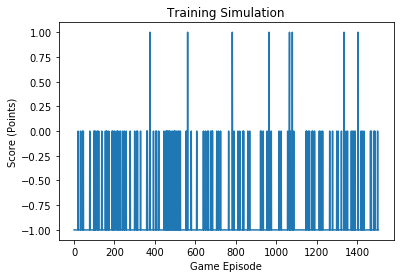

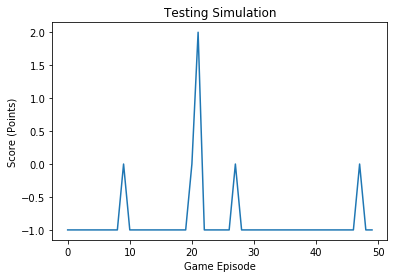

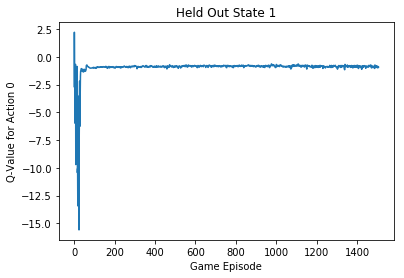

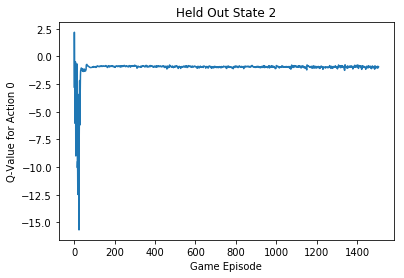

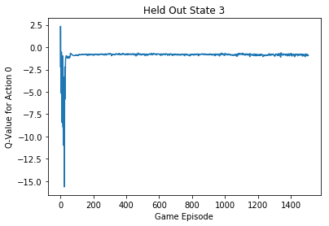

```python
# Set training parameters
train_time = 5
render = False
save_memory = True
pickup_training = False
pickup_epsilon = 0.1

# Initialize environment, models, and initial variables
fb_env = gym.make('FlappyBird-v0')

score_stats_train = list()
score_stats_test = list()
reward = 0
done = False
epsilon = start_epsilon
update_counter = 0
acts_counter = 0
episode_counter = 0
z_counter = 1
stop_learning = False
t_initial = time()


# Pick up training from last session or perform random actions
# to populate Replay Memory
if pickup_training:
    fb_Q.load_weights('fb_weights_after_training.hdf5')
    fb_model.load_weights('fb_model_weights_for_pickup.hdf5')
    epsilon = pickup_epsilon
else:
    r_memory.clear()
    while z_counter <= random_steps:
        frame = fb_env.reset()
        frame_sequence = deque([], maxlen=10)
        frame_sequence.append(frame)
        state_n = frames_to_stacktensor(frame_sequence)

        while True:
            if render:
                fb_env.render()
            action = fb_env.action_space.sample()

            for l in range(action_repeat):
                new_frame, partial_reward, done, info = fb_env.step(action)
                reward += partial_reward
                if done:
                    break

            frame_sequence.append(new_frame)
            state_nplus1 = frames_to_stacktensor(frame_sequence)
            if reward > 1:
                reward = 1
            if reward < -1:
                reward = -1
            transition = (state_n, action, reward, state_nplus1, done)
            r_memory.append(transition)
            z_counter += 1

            #Updates
            state_n = state_nplus1
            reward = 0

            if done:
                break
    print('Random play done')


# Hold out states to track progress
hold_outs = tuple(random.sample(r_memory, 3))
hold_out_tracker_0 = list()
hold_out_tracker_1 = list()
hold_out_tracker_2 = list()
hold_out_tracker_all = [hold_out_tracker_0,\
                       hold_out_tracker_1,\
                       hold_out_tracker_2]


# Start gameplay with reinforcement learning
while (((time()-t_initial)/60/60) < train_time) and (epsilon > final_epsilon):
    frame = fb_env.reset()
    frame_sequence = deque([], maxlen = 10)
    frame_sequence.append(frame)
    state_n = frames_to_stacktensor(frame_sequence)
    score = 0
    acts_in_episode = 0

    while True:
        if render:
            fb_env.render()

        # Choose random action according to probability
        # epsilon, else use CNN to calculate Q values
        # for action selection
        if random.random() < epsilon:
            action = fb_env.action_space.sample()
        else:
            Q_values = fb_Q.predict(state_n)
            action = np.argmax(Q_values)

        for t in range(action_repeat):
            new_frame, partial_reward, done, info = fb_env.step(action)
            reward += partial_reward
            if done:
                acts_counter += 1
                acts_in_episode += 1
                break

        frame_sequence.append(new_frame)
        state_nplus1 = frames_to_stacktensor(frame_sequence)
        if reward > 1:
                reward = 1
        if reward < -1:
                reward = -1
        transition = (state_n, action, reward, state_nplus1, done)
        r_memory.append(transition)


        # Train CNN on sample batch from replay memory according to training_frequency
        if acts_counter%training_frequency==0:
            memory_batch = random.sample(r_memory, training_batch_size)
            batch_preds, batch_targets = batch_to_targets_preds(memory_batch, fb_Q, fb_model)
            fb_Q.train_on_batch(batch_preds, batch_targets)
            acts_counter = 0
            update_counter += 1


        # Update target model
        if update_counter%update_frequency==0:
            fb_Q.save_weights('weights_for_update.hdf5')
            fb_model.load_weights('weights_for_update.hdf5')
            update_counter = 0


        # Updates
        state_n = state_nplus1
        score += reward
        reward = 0


        # When game ends, track metrics, priority sweep, and end loop
        if done:

            # Priority sweep: train on terminal state
            pred, target = transition_to_target_pred(transition, fb_Q, fb_model)
            fb_Q.fit(pred, target, batch_size=None, epochs=terminal_repeat, verbose=0)

            # Priority sweep: train on episode if agent performs well
            score_stats_train.append(score)
            if score > -1:
                pipes_passed = score + 1
                priority_repeat = int(priority_factor * pipes_passed)

                seq_batch = list()
                for w in range(acts_in_episode):
                    seq_batch.append(r_memory[len(r_memory) - (w + 1)])

                batch_preds, batch_targets = batch_to_targets_preds(seq_batch, fb_Q, fb_model)
                fb_Q.fit(batch_preds, batch_targets, batch_size=None, epochs=priority_repeat, verbose=0)

            # Decay exploration factor
            if epsilon > final_epsilon:
                epsilon -= ep_decay_rate
            else:
                epsilon = final_epsilon

            # Track Q value on held out states
            for u in range(len(hold_outs)):
                Q_hold_out = fb_Q.predict(hold_outs[u][0])
                hold_out_tracker_all[u].append(Q_hold_out[0][0])

            episode_counter += 1

            break


# Test agent in non-learning simulation
for i in range(50):
    frame = fb_env.reset()
    frame_sequence = deque([], maxlen = 10)
    frame_sequence.append(frame)
    state_n = frames_to_stacktensor(frame_sequence)
    score = 0

    while True:
        if render:
            fb_env.render()

        if random.random() < 0.05:
            action = fb_env.action_space.sample()
        else:
            Q_values = fb_Q.predict(state_n)
            action = np.argmax(Q_values)

        for t in range(action_repeat):
            new_frame, partial_reward, done, info = fb_env.step(action)
            reward += partial_reward
            if done:
                break

        frame_sequence.append(new_frame)
        state_nplus1 = frames_to_stacktensor(frame_sequence)
        if reward > 1:
                reward = 1
        if reward < -1:
                reward = -1
        transition = (state_n, action, reward, state_nplus1, done)


        # Updates
        state_n = state_nplus1
        score += reward
        reward = 0


        # When game ends, track metrics, and end loop
        if done:
            score_stats_test.append(score)
            break

fb_env.close()
fb_Q.save_weights('fb_weights_after_training.hdf5')
fb_model.save_weights('fb_model_weights_for_pickup.hdf5')
print('Simulation done')
print('Replay memory size: {}'.format(len(r_memory)))
if not save_memory:
    r_memory.clear()
    frame_sequence.clear()
print('Final epsilon: {}'.format(epsilon))
print('Episode count: {}'.format(episode_counter))

plt.plot(score_stats_train)
plt.ylabel('Score (Points)')
plt.xlabel('Game Episode')
plt.title('Training Simulation')
plt.show()

plt.plot(score_stats_test)
plt.ylabel('Score (Points)')
plt.xlabel('Game Episode')
plt.title('Testing Simulation')
plt.show()

plt.plot(hold_out_tracker_all[0])
plt.ylabel('Q-Value for Action 0')
plt.xlabel('Game Episode')
plt.title('Held Out State 1')
plt.show()

plt.plot(hold_out_tracker_all[1])
plt.ylabel('Q-Value for Action 0')
plt.xlabel('Game Episode')
plt.title('Held Out State 2')
plt.show()

plt.plot(hold_out_tracker_all[2])
plt.ylabel('Q-Value for Action 0')
plt.xlabel('Game Episode')
plt.title('Held Out State 3')
plt.show()
```

### Monster Kong Environment

This section operates the same way as the previous section, except agent operates in the Monster Kong environment.

```
Random play done
Simulation done
Replay memory size: 4000
Final epsilon: 0.7389150399999735
Episode count: 511
```

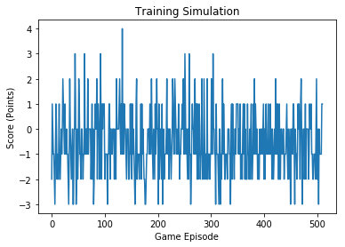

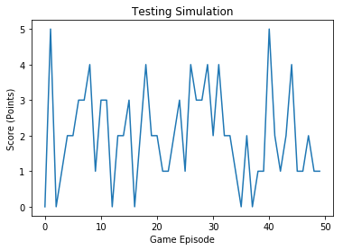

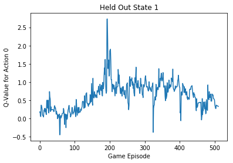

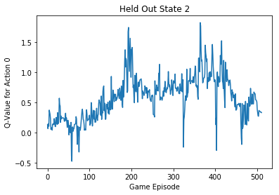

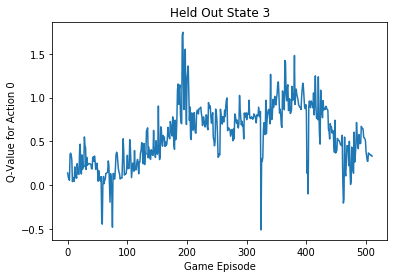

```python
# Set training parameters
train_time = 5
render = False
save_memory = True
pickup_training = False
pickup_epsilon = 0.1

# Initialize environment, models, and initial variables
mk_env = gym.make('MonsterKong-v0')

score_stats_train = list()
score_stats_test = list()
reward = 0
done = False
epsilon = start_epsilon
update_counter = 0
acts_counter = 0
episode_counter = 0
z_counter = 1
stop_learning = False
t_initial = time()


# Pick up training from last session or perform random actions
# to populate Replay Memory
if pickup_training:
    mk_Q.load_weights('mk_weights_after_training.hdf5')
    mk_model.load_weights('mk_model_weights_for_pickup.hdf5')
    epsilon = pickup_epsilon
else:
    r_memory.clear()
    while z_counter <= random_steps:
        frame = mk_env.reset()
        frame_sequence = deque([], maxlen=10)
        frame_sequence.append(frame)
        state_n = frames_to_stacktensor(frame_sequence)

        while True:
            if render:
                mk_env.render()
            action = mk_env.action_space.sample()

            for l in range(action_repeat):
                new_frame, partial_reward, done, info = mk_env.step(action)
                reward += partial_reward
                if done:
                    break

            frame_sequence.append(new_frame)
            state_nplus1 = frames_to_stacktensor(frame_sequence)
            if reward > 1:
                reward = 1
            if reward < -1:
                reward = -1
            transition = (state_n, action, reward, state_nplus1, done)
            r_memory.append(transition)
            z_counter += 1

            #Updates
            state_n = state_nplus1
            reward = 0

            if done:
                break
    print('Random play done')


# Hold out states to track progress
hold_outs = tuple(random.sample(r_memory, 3))
hold_out_tracker_0 = list()
hold_out_tracker_1 = list()
hold_out_tracker_2 = list()
hold_out_tracker_all = [hold_out_tracker_0,\
                       hold_out_tracker_1,\
                       hold_out_tracker_2]


# Start gameplay with reinforcement learning
while (((time()-t_initial)/60/60) < train_time) and (epsilon > final_epsilon):
    frame = mk_env.reset()
    frame_sequence = deque([], maxlen = 10)
    frame_sequence.append(frame)
    state_n = frames_to_stacktensor(frame_sequence)
    score = 0
    acts_in_episode = 0
    episode_time_start = time()

    while True:
        if render:
            mk_env.render()

        # Choose random action according to probability
        # epsilon, else use CNN to calculate Q values
        # for action selection
        if random.random() < epsilon:
            action = mk_env.action_space.sample()
        else:
            Q_values = mk_Q.predict(state_n)
            action = np.argmax(Q_values)

        for t in range(action_repeat):
            new_frame, partial_reward, done, info = mk_env.step(action)
            reward += partial_reward
            if done:
                acts_counter += 1
                acts_in_episode += 1
                break

        frame_sequence.append(new_frame)
        state_nplus1 = frames_to_stacktensor(frame_sequence)
        if reward > 1:
                reward = 1
        if reward < -1:
                reward = -1
        transition = (state_n, action, reward, state_nplus1, done)
        r_memory.append(transition)


        # Train CNN on sample batch from replay memory according to training_frequency
        if acts_counter%training_frequency==0:
            memory_batch = random.sample(r_memory, training_batch_size)
            batch_preds, batch_targets = batch_to_targets_preds(memory_batch, mk_Q, mk_model)
            mk_Q.train_on_batch(batch_preds, batch_targets)
            acts_counter = 0
            update_counter += 1


        # Update target model
        if update_counter%update_frequency==0:
            mk_Q.save_weights('weights_for_update.hdf5')
            mk_model.load_weights('weights_for_update.hdf5')
            update_counter = 0


        # Updates
        state_n = state_nplus1
        score += reward
        reward = 0


        # When game ends, track metrics, priority sweep, and end loop
        if done or ((time()-episode_time_start) > 300):

            # Priority sweep: train on terminal state
            pred, target = transition_to_target_pred(transition, mk_Q, mk_model)
            mk_Q.fit(pred, target, batch_size=None, epochs=terminal_repeat, verbose=0)

            # Priority sweep: train on episode if agent performs well
            score_stats_train.append(score)
            if score > -3 and acts_in_episode >= 1:
                score_above_baseline = score + 3
                priority_repeat = int(priority_factor * score_above_baseline)

                seq_batch = list()
                for w in range(acts_in_episode):
                    seq_batch.append(r_memory[len(r_memory) - (w + 1)])

                batch_preds, batch_targets = batch_to_targets_preds(seq_batch, mk_Q, mk_model)
                mk_Q.fit(batch_preds, batch_targets, batch_size=None, epochs=priority_repeat, verbose=0)

            # Decay exploration factor
            if epsilon > final_epsilon:
                epsilon -= ep_decay_rate
            else:
                epsilon = final_epsilon

            # Track Q value on held out states
            for u in range(len(hold_outs)):
                Q_hold_out = mk_Q.predict(hold_outs[u][0])
                hold_out_tracker_all[u].append(Q_hold_out[0][0])

            episode_counter += 1

            break


# Test agent in non-learning simulation
for i in range(50):
    frame = mk_env.reset()
    frame_sequence = deque([], maxlen = 10)
    frame_sequence.append(frame)
    state_n = frames_to_stacktensor(frame_sequence)
    score = 0
    episode_time_start = time()

    while True:
        if render:
            mk_env.render()

        if random.random() < 0.05:
            action = mk_env.action_space.sample()
        else:
            Q_values = mk_Q.predict(state_n)
            action = np.argmax(Q_values)

        for t in range(action_repeat):
            new_frame, partial_reward, done, info = mk_env.step(action)
            reward += partial_reward
            if done:
                break

        frame_sequence.append(new_frame)
        state_nplus1 = frames_to_stacktensor(frame_sequence)
        if reward > 1:
                reward = 1
        if reward < -1:
                reward = -1
        transition = (state_n, action, reward, state_nplus1, done)


        # Updates
        state_n = state_nplus1
        score += reward
        reward = 0


        # When game ends, track metrics, and end loop
        if done or ((time()-episode_time_start) > 300):
            score_stats_test.append(score)
            break

mk_env.close()
mk_Q.save_weights('mk_weights_after_training.hdf5')
mk_model.save_weights('mk_model_weights_for_pickup.hdf5')
print('Simulation done')
print('Replay memory size: {}'.format(len(r_memory)))
if not save_memory:
    r_memory.clear()
    frame_sequence.clear()
print('Final epsilon: {}'.format(epsilon))
print('Episode count: {}'.format(episode_counter))

plt.plot(score_stats_train)
plt.ylabel('Score (Points)')
plt.xlabel('Game Episode')
plt.title('Training Simulation')
plt.show()

plt.plot(score_stats_test)
plt.ylabel('Score (Points)')
plt.xlabel('Game Episode')
plt.title('Testing Simulation')
plt.show()

plt.plot(hold_out_tracker_all[0])
plt.ylabel('Q-Value for Action 0')
plt.xlabel('Game Episode')
plt.title('Held Out State 1')
plt.show()

plt.plot(hold_out_tracker_all[1])
plt.ylabel('Q-Value for Action 0')
plt.xlabel('Game Episode')
plt.title('Held Out State 2')
plt.show()

plt.plot(hold_out_tracker_all[2])
plt.ylabel('Q-Value for Action 0')
plt.xlabel('Game Episode')
plt.title('Held Out State 3')
plt.show()
```